# Avaliação 2 - Valor: 33 pontos

Introdução à Ciência de Dados - 2025  
Bacharelado em Administração

Autor

Prof. Dr. Washington S. da Silva

Data de Publicação

18 de junho de 2025

## Questão 1 (8 pontos)

### Tópico: Prêmio de Seguro e Simulação de Monte Carlo

Uma seguradora oferece seguro residencial contra incêndio para 10.000 residências. Os dados históricos disponíveis são:

| Parâmetro | Valor |
| --- | --- |
| Probabilidade anual de sinistro | **1%** |
| Indenização média por sinistro | **R$ 150.000** |
| Margem-alvo sobre o prêmio puro | **25%** |

**Termos técnicos**

- *Prêmio* = Valor esperado do sinistro por apólice
- *Prêmio comercial* = Prêmio + margem de 25% (lucro + custos administrativos)

**a)** (1 pto) Calcule o prêmio* com R (valor esperado da indenização por residência).

**b)** (1 pto) Calcule o prêmio comercial com R, incluindo a margem de 25%.

**Simulações de Monte Carlo:** A seguradora deseja observar como o **custo médio por apólice** se comporta em carteiras com diferentes números de residências seguradas. Complete e execute as três células de código a seguir para simular os custos e estimar o custo médio para carteiras com 10, 100 e 1.000 residências seguradas.

Use os seguintes parâmetros em todos os casos:

- Probabilidade de sinistro = 0,01
- Indenização em caso de sinistro = R$ 150.000,00

**c)** (3 ptos) Complete e execute o código R a seguir para simular os custos da seguradora e estimar o custo médio para o cenário com 10 residências seguradas:

```r
## fixa a semente para reprodutibilidade
set.seed(2025)

## simula o custo para 10 residências seguradas
custos_10 <- sample(
  c(____, ____),        # preencha com os dois valores de custos possíveis: sem sinistro e com sinistro
  size = ____,          # número total de residências a serem simuladas
  replace = ____,       # indique se a amostragem será com reposição
  prob = c(____, ____)  # probabilidades de cada um dos dois resultados (sinistro e não sinistro)
  )

## estimativa do custo médio por apólice com 10 residências seguradas
____(custos_10)         # função para calcular a média do vetor simulado
```

Simulação dos custos médios com 100 residências seguradas:

```r
# insira seu código aqui
```

Simulação dos custos médios com 1000 residências seguradas:

```r
# insira seu código aqui
```

**d)** (1 pto) Qual resultado teórico da teoria da probabilidade explica os resultados das simulações? Por que esse comportamento é importante para o mercado de seguros?

**e)** (2 ptos) A seguradora estuda incluir uma franquia fixa de R$ 50 000,00 em cada apólice contra incêndio, ou seja, o segurado precisa arcar com essa parcela em caso de incêndio. Explique, em linguagem simples e objetiva, **como** a franquia altera o valor que a seguradora efetivamente paga em caso de sinistro e **Por que** essa mudança pode reduzir o custo esperado por apólice e, assim, permitir (a) cobrar um prêmio menor **ou** (b) manter o prêmio e aumentar a margem de lucro.

## Questão 2 (4 pontos)

### Tópico: Distribuição Normal: Probabilidades e Quantis

Uma rede de farmácias deseja melhorar o planejamento de seus pedidos de reposição. O tempo de entrega (entre o envio do pedido e a chegada dos produtos ao estoque) tem se comportado como uma variável aleatória aproximadamente normal com:

$$X \sim N(\mu = 6{,}5\ \text{dias},\ \sigma = 1{,}8\ \text{dias})$$

**a)** (1 pto) Qual é a probabilidade de o tempo de entrega ser superior a 8 dias?

**b)** (2 pto) Qual é o prazo máximo de entrega que cobre 90% dos casos (isto é, tal que apenas 10% dos pedidos demorem mais do que esse valor)?

**c)** (1 pto) Suponha que a farmácia deseje prometer aos clientes uma entrega em até 7 dias, na maioria dos casos. Qual a probabilidade de que esse prazo seja cumprido, com base no histórico?

## Questão 3 (3 pontos)

### Tópico: Score Padronizado (score Z) e Comparação Relativa de Desempenho

Uma rede varejista está avaliando o desempenho diário de vendas de suas lojas. Com base no histórico de dados, sabe-se que:

- A média de vendas diárias das lojas é de R$ 18.500,00;
- O desvio-padrão é de R$ 2.300,00.

Em um determinado dia, uma das lojas registrou R$ 21.800,00 em vendas.

**a)** (1 pto) Calcule o score Z correspondente a esse valor, o que o valor calculado indica sobre o desempenho dessa loja?

**b)** (1 pto) Use a função `pnorm()` para calcular a probabilidade acumulada até esse valor de vendas, com base no z-score. Essa probabilidade indica a posição da loja no ranking de desempenho naquele dia. O que esse valor indica sobre o desempenho da loja em relação às demais?

**Podemos usar percentil e probabilidade acumulada como sinônimos neste caso?**

Sim, Quando usamos a distribuição normal para comparar um valor com os demais — como no caso da venda de uma loja em relação às demais — o resultado da função `pnorm()` nos diz a proporção de valores abaixo daquele valor.

Por exemplo, se uma loja vendeu R$ 21.800 e `pnorm()` retorna 0,7, isso significa que 70,0% das lojas venderam menos que ela.

Esse valor acumulado pode ser interpretado como o percentil em que essa loja se encontra.

👉 Portanto, neste tipo de aplicação, a probabilidade acumulada até um ponto e o percentil correspondente representam a mesma quantidade: “Qual a fração (ou porcentagem) de casos abaixo deste valor?”

**c)** (1 pto) A empresa considera que um desempenho é excepcional quando a loja está entre as **10% com melhores vendas** do dia. Esse dia foi excepcional para essa loja? Explique.

## Questão 4 (5 pontos)

### Tópico: Valor-em-Risco (VaR) sob a Distribuição Normal

Considere um portfólio cujo retorno mensal segue $N(\mu=1{,}1\%,\ \sigma=4{,}2\%)$. Investimento atual: R$ 400 000.

**a)** (2 ptos) Calcule o Valor-em-Risco (VaR) 99 %, percentual e monetário.

**b)** (1 pto) Interprete o valor monetário do VaR 99 %.

**c)** (2 ptos) Descreva duas características (relacionadas à forma da distribuição) que, se presentes na distribuição real dos retornos, tornariam inadequada a suposição de que os retornos de ativos financeiros seguem uma distribuição aproximadamente normal.

## Questão 5 (ENADE/2022) (5 pontos)

### Tópico: Interpretação de Gráficos com Frequência Absoluta (Número Absoluto) e Relativa (Taxa ou Proporção)

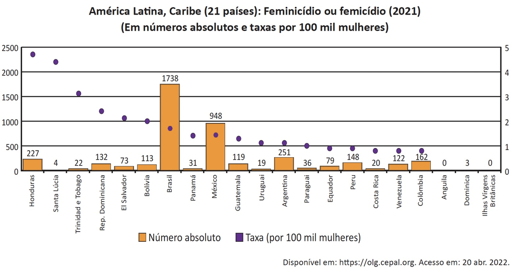

Figura 1: Gráfico de Barras e Gráfico de Pontos

Resultados de pesquisa da Comissão Econômica para a América Lati na e o Caribe (CEPAL), vinculada à Organização das Nações Unidas (ONU), apontam que, além do feminicídio íntimo, aquele perpetrado por parceiros ou ex-parceiros da vítima, e do feminicídio sexual sistêmico, em que a vítima é sequestrada e estuprada, há o feminicídio lesbofóbico ou bifóbico, configurado quando a víti ma é bissexual ou lésbica e é assassinada porque o agressor entende que deve puni-la por sua orientação sexual.

A partir da Fig. 1 e das informações do texto, assinale a opção correta (1 pto) e **explique**, de forma **concisa e objetiva**, por que as demais estão incorretas (4 ptos)

A - O gráfico apresentado ranqueia os países a parti r de um cálculo de proporção e, nessa perspectiva, Santa Lúcia apresenta uma das taxas mais baixas de feminicídio na região.

B - As políticas públicas voltadas às mulheres partem do pressuposto de que elas devem ser as principais responsáveis por sua própria segurança, evitando comportamentos de risco.

C - Os países da América Lati na que apresentam as maiores taxas de ocorrência de feminicídios a cada 100 mil mulheres, de acordo com o gráfico apresentado, são Brasil, México e Argentina.

D - As formas de violência que afetam as mulheres são determinadas não somente pela condição sexual e de gênero, mas também por diferenças econômicas, etárias, raciais, culturais e religiosas.

E - O número relativo a cada 100 mil mulheres víti mas de feminicídio no Brasil explica a posição elevada do país no ranking, diferentemente de Honduras, que registra, relati vamente, menos ocorrências que o Brasil.

## Questão 6 (8 pontos)

### Tópico: Correlação ente Variáveis Aleatórias e Gráfico de Dispersão

Use a função `tq_get()` do pacote tidyquant para baixar os preços de fechamento diários das ações `PETR4.SA` e `WEGE3.SA` a partir de `2024-01-01` e execute as tarefas abaixo.

**a)** (2 ptos) Crie **um único pipeline com exatamente cinco linhas** que:

1. recebe o vetor de símbolos `c("PETR4.SA", "WEGE3.SA")`,
2. importa as séries de preços diários do Yahoo Finance,
3. seleciona as variáveis `symbol`, `date`, `close`,
4. converte para formato *wide* com `pivot_wider()`,
5. renomeia as colunas para `petrobras` e `weg`.

Salve o resultado em `dados_precos` e exiba suas primeiras linhas.

```r
# insira seu código aqui
```

2. Estimativa do Correlação de Pearson dos Retornos logarítmicos

**b.1)** (1 pto) Construa a data frame `dados_ret`, contendo os **retornos logarítmicos diários** das duas ações (a primeira observação será perdida). Para isso, usando a data frame `dados_precos` obtida no item anterior, execute o código a seguir:

```r
# cálculo dos retornos logarítmicos
dados_ret <- dados_precos %>%
# a função `mutate()` adiciona as colunas de retornos
mutate(ret_petrobras = log(petrobras / lag(petrobras)),
     ret_weg       = log(weg       / lag(weg))) %>%
# drop_na remove a linha com retorno faltante (NA)
drop_na()

# exibição das primeiras linhas
head(dados_ret)
```

**Por que retornos ao invés de preços?**

- Retornos logarítmicos (também chamados retornos compostos continuamente) são calculados como:

$$\text{retorno} = \log\left(\frac{\text{preço atual}}{\text{preço anterior}}\right) =
\log\left(\frac{P_t}{P_{t-1}}\right) = \log(P_t) - \log(P_{t-1})$$

- As análises de correlação, regressão e diversificação devem ser feitas sobre **retornos** (e não sobre preços), pois, como vimos em aula, retornos tendem a apresentar propriedades estatísticas mais adequadas do que séries de preços, por exemplo, o retorno médio e a variância dos retornos são mais estáveis ao longo do tempo.

**b.2)** (1 pto) Estime o coeficiente de correlação de Pearson entre as duas séries de retornos diários, usando a função interna `cor()` de R.

```r
# insira seu código aqui
```

**b.3)** (1 pto) Interprete a magnitude do coeficinte de correlacão estimado usando a função `effectsize::interpret_r()` e os critérios de Cohen (1988).

```r
# insira seu código aqui
```

**c)** (2 ptos) Construa um gráfico de dispersão entre `ret_petrobras` e `ret_weg`, incluindo:

- reta de regressão (`geom_smooth(method = "lm", se = FALSE)`),
- título, subtítulo com período dos dados, rótulos (nomes) adequados para os eixos e fonte dos dados.

E interprete o gráfico.

```r
# insira seu código aqui
```

**d)** (1 pto) Explique se a combinação PETR4 + WEGE3 contribui para diversificação de uma carteira composta por esses dois ativos.